# Matthew Bierman, Project 1

# Dataset #1: Kickstarter

### Introduction

I will be performing *classification* on this Kickstarter dataset to predict if a project did or did not succeed. This dataset can be found at https://www.kaggle.com/kemical/kickstarter-projects, and I will be using the ks-projects-201801.csv file.

### Load Data

The Kickstarter dataset has been read from a .csv file and stored in the ‘kickstarterData’ variable. It has 378,661 rows (examples) and 15 columns (features).

```r
# Read data from .csv file
kickstarterData <- read.csv(file = "ks-projects-201801.csv", header = TRUE, sep = ",")

# Get dimensions of data
dim(kickstarterData)
```

```
## [1] 378661     15
```

### Take Sample of Data

Since this is such a large dataset (over 300,000 examples and a .csv file of 58MB), I have randomly selected 40% of the data to use for this project. 40% of the dataset is still rather large (~ 151,464 rows), but it will make computations significantly faster when running the R Markdown file.

```r
# Set seed
set.seed(4375)

# Take 40% random sample of dataset and replace it with current dataset
i <- sample(1:nrow(kickstarterData), nrow(kickstarterData) * 0.4, replace = FALSE)
kickstarterData <- kickstarterData[i, ]
```

### Data Examination

dim() returns the dimensions of the dataset. There are 151,464 rows (examples) and 15 columns (features).

```r
# Data Examination Function #1
dim(kickstarterData)
```

```
## [1] 151464     15
```

names() returns the names of the dataset’s 15 features. str() will be used next to get the data types for each feature.

```r
# Data Examination Function #2
names(kickstarterData)
```

```
##  [1] "ID"               "name"             "category"
##  [4] "main_category"    "currency"         "deadline"
##  [7] "goal"             "launched"         "pledged"
## [10] "state"            "backers"          "country"
## [13] "usd.pledged"      "usd_pledged_real" "usd_goal_real"
```

str() returns the data types of the dataset’s features and a preview of the values for each feature from the dataset’s examples. Here is what each of the features mean:

- `ID`: ID of the Kickstarter project
- `name`: Title of the project
- `category`: Specific category of the project
- `main_category`: Main category of the project
- `currency`: Type of units for the `goal` and `pledged` features (e.g. US Dollar, Euro, etc.)
- `deadline`: Date the project will stop accepting donations, regardless if it met its goal
- `goal`: Amount of money (units of amount is determined by `currency`) the project creator hopes to reach and/or exceed
- `launched`: Date the project was launched
- `pledged`: Amount of money (units of amount is determined by `currency`) donated to the project
- `state`: Status of the project (if it succeeded, failed, etc.)
- `backers`: Number of people who donated to the project
- `country`: Location of the project
- `usd.pledged`: Amount in `pledged` converted (conversions done by Kickstarter) to US Dollar
- `usd_pledged_real`: Amount in `pledged` converted (conversions done by Fixer.io API) to US Dollar
- `usd_goal_real`: Amount in `goal` converted (conversions done by Fixer.io API) to US Dollar

```r
# Data Examination Function #3
str(kickstarterData)
```

```
## 'data.frame':    151464 obs. of  15 variables:
##  $ ID              : int  148186602 1116975240 1671756909 238566094 1551751379 1353363716 1560219033 899255296 1868287482 989405919 ...
##  $ name            : Factor w/ 375765 levels "","    IT’S A HOT CAPPUCCINO NIGHT  ",..: 144720 1311 66263 8162 143072 133267 265111 341226 160386 238848 ...
##  $ category        : Factor w/ 159 levels "3D Printing",..: 91 124 36 35 91 137 48 106 137 104 ...
##  $ main_category   : Factor w/ 15 levels "Art","Comics",..: 11 8 5 4 11 9 11 12 9 12 ...
##  $ currency        : Factor w/ 14 levels "AUD","CAD","CHF",..: 14 6 6 14 14 14 11 14 14 14 ...
##  $ deadline        : Factor w/ 3164 levels "2009-05-03","2009-05-16",..: 1349 2107 2448 1434 722 3054 2923 2407 2444 2419 ...
##  $ goal            : num  300 200000 5000 2500 4000 100 500 7000 20000 8000 ...
##  $ launched        : Factor w/ 378089 levels "1970-01-01 01:00:00",..: 86663 205012 276796 94628 21504 372229 349286 269615 277504 271295 ...
##  $ pledged         : num  375 55 830 2676 925 ...
##  $ state           : Factor w/ 6 levels "canceled","failed",..: 4 2 2 4 2 4 2 2 4 2 ...
##  $ backers         : int  16 2 9 46 20 22 2 2 511 8 ...
##  $ country         : Factor w/ 23 levels "AT","AU","BE",..: 23 10 10 23 23 23 20 23 23 23 ...
##  $ usd.pledged     : num  375 84.9 1205.2 2676.5 925 ...
##  $ usd_pledged_real: num  375 82.6 1202.4 2676.5 925 ...
##  $ usd_goal_real   : num  300 300431 7244 2500 4000 ...
```

head() returns a preview of the data (the first six lines). I will use `state` as my target for this project. Furthermore, I want to predict whether a Kickstarter project succeeds or fails. Project success is defined as a project meeting or exceeding its monetary goal (donated by backers) before the given deadline, and project failure is defined as a project not meeting its monetary goal before the given deadline.

```r
# Data Examination Function #4
head(kickstarterData)
```

```
##                ID
## 94807   148186602
## 23051  1116975240
## 132369 1671756909
## 229854  238566094
## 108536 1551751379
## 69426  1353363716
##                                                                name
## 94807                       Help make the "Papyrus" project happen!
## 23051  'Sasushtini' - Sashimi, Sushi & Miniturised Cocktail Concept
## 132369                           Carved 3D wooden city street maps.
## 229854    "Subject To Change." A site-specific outdoor dance piece.
## 108536                              Help Buffalo Clover Go On Tour!
## 69426                                         Gone... In 61 Seconds
##              category main_category currency   deadline   goal
```

[output cut: 20 more lines]

summary() returns a distribution summary for the data. Numeric/int variables (`ID`, `goal`, `pledged`, `backers`, `usd.pledged`, `usd_pledged_real`, `usd_goal_real`) show the quartile distribution for each feature and factor variables (`name`, `category`, `main_category`, `currency`, `deadline`, `launched`, `state`, `country`) show the six most frequent values for each feature.

```r
# Data Examination Function #5
summary(kickstarterData)
```

```
##        ID                                    name
##  Min.   :3.387e+04   New EP/Music Development  :    17
##  1st Qu.:5.404e+08   Canceled (Canceled)       :     7
##  Median :1.079e+09   Debut Album               :     5
##  Mean   :1.077e+09   Music Video               :     5
##  3rd Qu.:1.613e+09   New EP / Music Development:     5
##  Max.   :2.147e+09   Pasta Salad               :     5
##                      (Other)                   :151420
##            category           main_category      currency
##  Product Design:  9026   Film & Video:25408   USD    :118235
##  Documentary   :  6521   Music       :20717   GBP    : 13743
##  Music         :  6287   Publishing  :15996   EUR    :  6938
##  Tabletop Games:  5618   Games       :13971   CAD    :  5875
##  Shorts        :  4964   Technology  :12981   AUD    :  3151
##  Video Games   :  4699   Design      :12129   MXN    :   711
##  (Other)       :114349   (Other)     :50262   (Other):  2811
##        deadline           goal                          launched
##  2014-08-08:   298   Min.   :        0   2011-02-25 09:58:36:     2
##  2014-08-10:   228   1st Qu.:     2000   2012-01-13 14:10:48:     2
##  2014-08-07:   224   Median :     5000   2012-04-19 01:42:00:     2
##  2014-08-09:   201   Mean   :    48152   2012-05-03 20:08:18:     2
##  2015-05-01:   193   3rd Qu.:    16000   2012-06-07 18:47:22:     2
##  2014-08-31:   181   Max.   :100000000   2012-08-15 23:06:40:     2
##  (Other)   :150139                       (Other)            :151452
##     pledged                state          backers            country
##  Min.   :       0   canceled  :15546   Min.   :     0.0   US     :117166
##  1st Qu.:      31   failed    :78857   1st Qu.:     2.0   GB     : 13572
##  Median :     630   live      : 1111   Median :    12.0   CA     :  5784
##  Mean   :    9697   successful:53810   Mean   :   105.4   AU     :  3106
##  3rd Qu.:    4071   suspended :  739   3rd Qu.:    56.0   DE     :  1645
##  Max.   :13285226   undefined : 1401   Max.   :219382.0   N,0"   :  1491
##                                                           (Other):  8700
##   usd.pledged       usd_pledged_real   usd_goal_real
##  Min.   :       0   Min.   :       0   Min.   :        0
##  1st Qu.:      18   1st Qu.:      31   1st Qu.:     2000
##  Median :     400   Median :     635   Median :     5416
##  Mean   :    7158   Mean   :    9112   Mean   :    44873
##  3rd Qu.:    3045   3rd Qu.:    4045   3rd Qu.:    15184
##  Max.   :13285226   Max.   :13285226   Max.   :166361391
##  NA's   :1491
```

### Data Cleaning

After seeing the summary of the dataset, I realized that `state` has more options than just successful and failed, from what I could see using head(); there are actually six different options for `state`: canceled, failed, live, successful, suspended, and undefined. Live, suspended, and undefined each contribute to less than 1% of the dataset, as shown in the graph below.

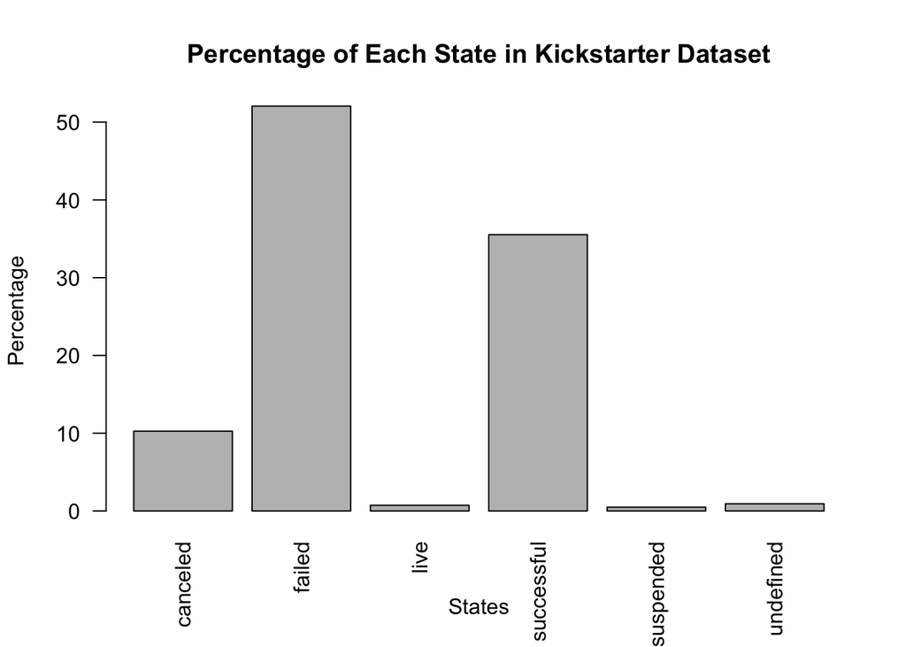

```r
# Graph #1
barplot(table(kickstarterData$state) / nrow(kickstarterData) * 100, main = "Percentage of Each State in Kickstarter Dataset", xlab = "States", ylab = "Percentage", las = 2)
```

Since it is impossible (given the current data, it would be impossible) to predict if a project is suspended or undefined and there is no benefit in predicting if a project is live, I will remove all examples containing any of those three states. Since the three combined states make up less than 3% of the entire dataset, it is not an issue.

```r
# Removed data that have states live, suspended, or undefined
kickstarterData <- kickstarterData[kickstarterData$state != "live" & kickstarterData$state != "suspended" & kickstarterData$state != "undefined",]
```

The amount of time that a project is collecting donations could be important, since a project that is only live for a few days won’t get as much exposure as a project that is live for a few weeks, which could mean less people backing the project. I think the time length of the project might affect whether a project is successful or not, so I extracted the month, day, and year from `deadline` and `launched` and took the difference of the two using difftime() to get the number of days a project was live. I then stored that information in the `time_length` numeric variable.

```r
# Use only month, day, and year for deadline & launched
kickstarterData$deadline <- substr(kickstarterData$deadline, 0, 10)
kickstarterData$launched <- substr(kickstarterData$launched, 0, 10)
kickstarterData$time_length <- as.numeric(difftime(kickstarterData$deadline, kickstarterData$launched, units = "days"))
```

When using logistic regression in future steps, problems arise when some variables are integers and others are numeric, so I converted `backers` from an integer variable to a numeric variable.

```r
# Convert int in 'backers' to numeric
kickstarterData$backers <- as.numeric(kickstarterData$backers)
```

Since it will be difficult with the given data to predict if a project was canceled (it only makes up about 10% of the dataset, as shown in the previous graph), I will use the “one-versus-all” technique for multiclass classification to create a binary classification. For this dataset, I will predict if a Kickstarter project succeeded or did not succeed. To do this, I created a feature called `success`, where `1` means the project was successful and `0` means the project did not succeed (e.g. the project failed or was canceled).

```r
# Add 'success feature'
kickstarterData$success <- ifelse (kickstarterData$state == "successful", 1, 0)
kickstarterData$success <- as.factor(kickstarterData$success)
head(kickstarterData)
```

```
##                ID
## 94807   148186602
## 23051  1116975240
## 132369 1671756909
## 229854  238566094
## 108536 1551751379
## 69426  1353363716
##                                                                name
## 94807                       Help make the "Papyrus" project happen!
## 23051  'Sasushtini' - Sashimi, Sushi & Miniturised Cocktail Concept
## 132369                           Carved 3D wooden city street maps.
## 229854    "Subject To Change." A site-specific outdoor dance piece.
## 108536                              Help Buffalo Clover Go On Tour!
## 69426                                         Gone... In 61 Seconds
##              category main_category currency   deadline   goal   launched
```

[output cut: 20 more lines]

When looking at the graphs below for `backers`, `usd_pledged_real`, `usd_goal_real`, and `time_length`, there seems to be distinct clusters except when comparing `backers` and `usd_pledged_real`.

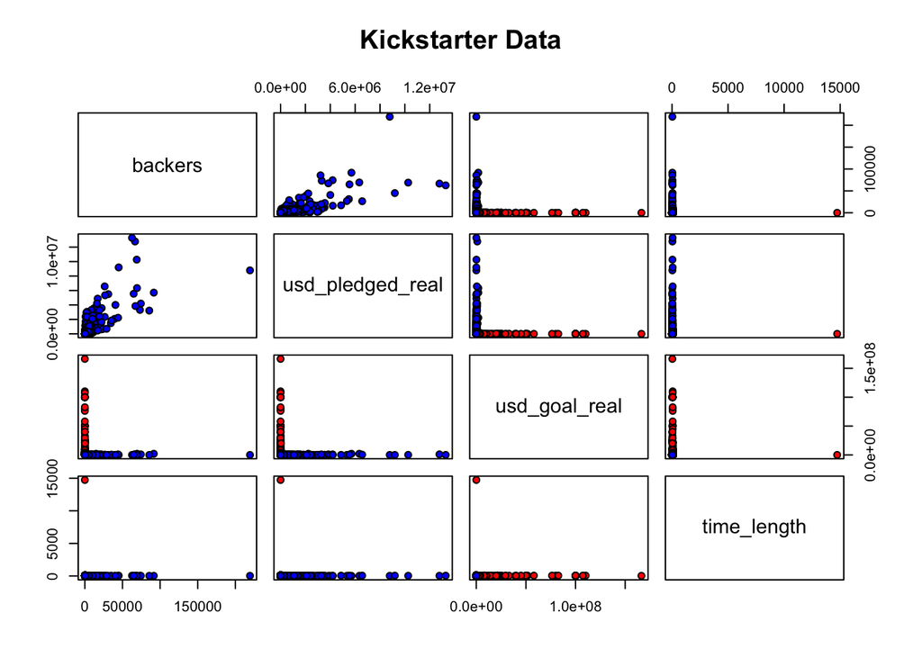

```r
# Graph #2
pairs(kickstarterData[c(11, 14:16)], main = "Kickstarter Data", pch = 21, bg = c("red", "blue")[unclass(kickstarterData$success)])
```

After some testing, I have selected `backers`, `usd_pledged_real`, `usd_goal_real`, and `time_length` as the features used in this classification. All other features have been removed from the dataset.

```r
# Remove features
kickstarterData <- kickstarterData[, -c(1:10, 12:13)]
```

The dataset has been split into 75% training data and 25% testing data.

```r
# Split into testing and training
set.seed(4375)
i <- sample(1:nrow(kickstarterData), nrow(kickstarterData) * 0.75, replace = FALSE)
train <- kickstarterData[i, ]
test <- kickstarterData[-i, ]
```

### Logistic Regression

```r
# Logistic Regression Model
glm <- glm(success~., data = train, family = "binomial")
# Accuracy for Logistic Regression
probs <- predict(glm, newdata = test, type = "response")
pred <- ifelse(probs > 0.5, 1, 0)
table(pred, test$success)
```

```
##
## pred     0     1
##    0 23316     3
##    1   434 13301
```

```r
paste("Accuracy: ", round(mean(pred == test$success) * 100, 2), "%", sep = "")
```

```
## [1] "Accuracy: 98.82%"
```

```r
summary(pred)
```

```
##    Min. 1st Qu.  Median    Mean 3rd Qu.    Max.
##  0.0000  0.0000  0.0000  0.3707  1.0000  1.0000
```

### kNN

```r
# kNN
library(class)
pred <- knn(train = train, test = test, cl = train$success, k = sqrt(nrow(kickstarterData)))

# Accuracy for kNN
table(pred, test$success)
```

```
##
## pred     0     1
##    0 23449    52
##    1   301 13252
```

```r
paste("Accuracy: ", round(mean(pred == test$success) * 100, 2), "%", sep = "")
```

```
## [1] "Accuracy: 99.05%"
```

```r
summary(pred)
```

```
##     0     1
## 23501 13553
```

### Summary & Analysis

Both algorithms performed extremely well on the dataset, with Logistic Regression resulting in a 98.82% accuracy on the test set and kNN resulting in a 99.05% accuracy on the test set. All kNN results performed around the 97-99% range with different k values, but k = sqrt(nrow(kickstarterData)) performed the best.

Logistic Regression seemed to be a bit lopsided in its errors: 3 times it predicted ‘Not Successful’ but its true value was ‘Successful’ and 434 times it predicted ‘Successful’ but its true value was ‘Not Successful’. kNN reported similar errors, most being in falsely predicting ‘Success’, but not as lopsided. I believe this error could arise from a large amount of backers for a project, but all of the backers donating small amounts, so the project is unable to met its goal.

kNN performed slightly better than Logistic Regression, and this may have been because it formed clusters around the `usd_pledged_real` variable, so projects that had similar amounts of donation were grouped together. This helped predict if a project was successful because projects that receive large amounts of donations tend to succeed and projects that receive small amounts of donations tend to not succeed.

# Dataset #2: TMDB 5000 Movies

### Introduction

I will be performing *regression* on this movie dataset to predict a movie’s popularity. This dataset can be found at https://www.kaggle.com/tmdb/tmdb-movie-metadata, and I will be using the tmdb_5000_movies.csv file.

### Load Data

The movie dataset has been read from a .csv file and stored in the ‘movieData’ variable.

```r
movieData <- read.csv(file = "tmdb_5000_movies.csv", header = TRUE, sep = ",")
```

### Data Examination (Part 1)

dim() returns the dimensions of the dataset. There are 4,803 rows (examples) and 20 columns (features).

```r
# Data Examination Function #1
dim(movieData)
```

```
## [1] 4803   20
```

```r
# Data Examination Function #2
names(movieData)
```

```
##  [1] "budget"               "genres"               "homepage"
##  [4] "id"                   "keywords"             "original_language"
##  [7] "original_title"       "overview"             "popularity"
## [10] "production_companies" "production_countries" "release_date"
## [13] "revenue"              "runtime"              "spoken_languages"
## [16] "status"               "tagline"              "title"
## [19] "vote_average"         "vote_count"
```

str() returns the data types of the dataset’s features and a preview of the values for each feature from the dataset’s examples. Here is what each of the features mean:

- `budget`: Budget (in US Dollars) to create the movie
- `genres`: Genre(s) of the movie
- `homepage`: Homepage URL of the movie
- `id`: ID of the movie
- `keywords`: Keywords that describe the movie
- `original_language`: Language the movie was originally filmed in
- `original_title`: Title of the movie (Will be different if `original_language` is not English)
- `overview`: Text summary of the movie
- `popularity`: As described by https://developers.themoviedb.org/3/getting-started/popularity, popularity of a movie is based on: number of votes for the day, number of views for the day, number of users who marked it as a “favourite” for the day, number of users who added it to their “watchlist” for the day, release date, number of total votes, and previous days score
- `production_companies`: Companies who worked on the movie
- `production_countries`: Countries in which the movie was produced
- `release_date`: Day, month, and year the movie was released
- `revenue`: Amount (in US Dollars) earned from the movie
- `runtime`: Length (in time) of the movie
- `spoken_languages`: Language(s) spoken in the movie
- `status`: Production status of the movie (has the movie been released, is it still in production, or has it not even been started yet)
- `tagline`: Tagline of the movie
- `title`: Title of the movie
- `vote_average`: Average value of votes for the movie (A vote has a value between 1 and 10)
- `vote_count`: Number of people who submitted a vote for the movie

```r
# Data Examination Function #3
str(movieData)
```

```
## 'data.frame':    4803 obs. of  20 variables:
##  $ budget              : int  237000000 300000000 245000000 250000000 260000000 258000000 260000000 280000000 250000000 250000000 ...
##  $ genres              : Factor w/ 1175 levels "[]","[{\"id\": 10402, \"name\": \"Music\"}, {\"id\": 10749, \"name\": \"Romance\"}]",..: 609 144 675 792 678 301 341 678 124 610 ...
##  $ homepage            : Factor w/ 1692 levels "","http://2016themovie.com/",..: 462 58 1282 1379 219 1285 66 192 138 475 ...
##  $ id                  : int  19995 285 206647 49026 49529 559 38757 99861 767 209112 ...
##  $ keywords            : Factor w/ 4222 levels "[]","[{\"id\": 100, \"name\": \"slum\"}, {\"id\": 1009, \"name\": \"baby\"}, {\"id\": 1721, \"name\": \"fight\"}, {\"| __truncated__,..: 535 1609 2618 3893 3779 3895 633 3923 3245 3891 ...
##  $ original_language   : Factor w/ 37 levels "af","ar","cn",..: 8 8 8 8 8 8 8 8 8 8 ...
##  $ original_title      : Factor w/ 4801 levels "...E tu vivrai nel terrore! L'aldilà",..: 374 2671 3195 3597 1897 3207 3368 375 1577 437 ...
##  $ overview            : Factor w/ 4801 levels ""," ","'Breaking Upwards' explores a young, real-life New York couple who, four years in and battling codependency, de"| __truncated__,..: 2526 1666 172 2082 2801 3918 4638 4670 1417 2042 ...
##  $ popularity          : num  150.4 139.1 107.4 112.3 43.9 ...
##  $ production_companies: Factor w/ 3697 levels "[]","[{\"name\": \"100 Bares\", \"id\": 5517}, {\"name\": \"Haddock Films S.R.L.\", \"id\": 5623}, {\"name\": \"Inst"| __truncated__,..: 1395 3541 528 1563 3578 566 3568 1700 3606 724 ...
##  $ production_countries: Factor w/ 469 levels "[]","[{\"iso_3166_1\": \"AE\", \"name\": \"United Arab Emirates\"}, {\"iso_3166_1\": \"GB\", \"name\": \"United King"| __truncated__,..: 441 466 300 466 466 466 466 466 300 466 ...
##  $ release_date        : Factor w/ 3281 levels "","1916-09-04",..: 2315 1945 3185 2688 2635 1940 2450 3111 2246 3234 ...
##  $ revenue             : num  2.79e+09 9.61e+08 8.81e+08 1.08e+09 2.84e+08 ...
##  $ runtime             : num  162 169 148 165 132 139 100 141 153 151 ...
##  $ spoken_languages    : Factor w/ 544 levels "[]","[{\"iso_639_1\": \"af\", \"name\": \"Afrikaans\"}, {\"iso_639_1\": \"en\", \"name\": \"English\"}, {\"iso_639_1"| __truncated__,..: 180 384 404 384 384 252 384 384 384 384 ...
##  $ status              : Factor w/ 3 levels "Post Production",..: 2 2 2 2 2 2 2 2 2 2 ...
##  $ tagline             : Factor w/ 3945 levels "","-If anyone asks.",..: 739 417 194 2839 1833 2664 3298 178 640 1700 ...
##  $ title               : Factor w/ 4800 levels "(500) Days of Summer",..: 381 2653 3186 3614 1906 3198 3364 382 1587 444 ...
##  $ vote_average        : num  7.2 6.9 6.3 7.6 6.1 5.9 7.4 7.3 7.4 5.7 ...
##  $ vote_count          : int  11800 4500 4466 9106 2124 3576 3330 6767 5293 7004 ...
```

head() returns a preview of the data. Since there is a lot of information, I decided to display only the first two lines. I will use `popularity` as the target for this project.

```r
# Data Examination Function #4
head(movieData, n = 2)
```

```
##      budget
## 1 237000000
## 2 300000000
##                                                                                                                                   genres
## 1 [{"id": 28, "name": "Action"}, {"id": 12, "name": "Adventure"}, {"id": 14, "name": "Fantasy"}, {"id": 878, "name": "Science Fiction"}]
## 2                                         [{"id": 12, "name": "Adventure"}, {"id": 14, "name": "Fantasy"}, {"id": 28, "name": "Action"}]
##                                       homepage    id
## 1                  http://www.avatarmovie.com/ 19995
## 2 http://disney.go.com/disneypictures/pirates/   285
##                                                                                                                                                                                                                                                                                                          …
## 1 [{"id": 1463, "name": "culture clash"}, {"id": 2964, "name": "future"}, {"id": 3386, "name": "space war"}, {"id": 3388, "name": "space colony"}, {"id": 3679, "name": "society"}, {"id": 3801, "name": "space travel"}, {"id": 9685, "name": "futuristic"}, {"id": 9840, "name": "romance"}, {"id": 988…
## 2                                                                                                                                                  [{"id": 270, "name": "ocean"}, {"id": 726, "name": "drug abuse"}, {"id": 911, "name": "exotic island"}, {"id": 1319, "name": "east india trading compa…
##   original_language                           original_title
## 1                en                                   Avatar
## 2                en Pirates of the Caribbean: At World's End
##                                                                                                                                                                           overview
## 1  In the 22nd century, a paraplegic Marine is dispatched to the moon Pandora on a unique mission, but becomes torn between following orders and protecting an alien civilization.
## 2 Captain Barbossa, long believed to be dead, has come back to life and is headed to the edge of the Earth with Will Turner and Elizabeth Swann. But nothing is quite as it seems.
##   popularity
## 1   150.4376
## 2   139.0826
##                                                                                                                                                                                          production_companies
## 1 [{"name": "Ingenious Film Partners", "id": 289}, {"name": "Twentieth Century Fox Film Corporation", "id": 306}, {"name": "Dune Entertainment", "id": 444}, {"name": "Lightstorm Entertainment", "id": 574}]
## 2                                                               [{"name": "Walt Disney Pictures", "id": 2}, {"name": "Jerry Bruckheimer Films", "id": 130}, {"name": "Second Mate Productions", "id": 19936}]
##                                                                                         production_countries
## 1 [{"iso_3166_1": "US", "name": "United States of America"}, {"iso_3166_1": "GB", "name": "United Kingdom"}]
## 2                                                 [{"iso_3166_1": "US", "name": "United States of America"}]
##   release_date    revenue runtime
## 1   2009-12-10 2787965087     162
## 2   2007-05-19  961000000     169
##                                                                         spoken_languages
## 1 [{"iso_639_1": "en", "name": "English"}, {"iso_639_1": "es", "name": "Espa\\u00f1ol"}]
## 2                                               [{"iso_639_1": "en", "name": "English"}]
##     status                                        tagline
## 1 Released                    Enter the World of Pandora.
## 2 Released At the end of the world, the adventure begins.
##                                      title vote_average vote_count
## 1                                   Avatar          7.2      11800
## 2 Pirates of the Caribbean: At World's End          6.9       4500
```

summary() returns a distribution summary for the data. Numeric/int variables (`budget`, `id`, `popularity`, `revenue`, `runtime`, `vote_average`, `vote_count`) show the quartile distribution for each feature and factor variables (`genres`, `homepage`, `keywords`, `original_language`, `original_title`, `overview`, `production_companies`, `production_countries`, `release_date`, `spoken_languages`, `status`, `tagline`, `title`) show the six most frequent values for each feature.

```r
# Data Examination Function #5
summary(movieData)
```

```
##      budget
##  Min.   :        0
##  1st Qu.:   790000
##  Median : 15000000
##  Mean   : 29045040
##  3rd Qu.: 40000000
##  Max.   :380000000
##
##                                                                                            genres
##  [{"id": 18, "name": "Drama"}]                                                                : 370
##  [{"id": 35, "name": "Comedy"}]                                                               : 282
##  [{"id": 18, "name": "Drama"}, {"id": 10749, "name": "Romance"}]                              : 164
##  [{"id": 35, "name": "Comedy"}, {"id": 10749, "name": "Romance"}]                             : 144
##  [{"id": 35, "name": "Comedy"}, {"id": 18, "name": "Drama"}]                                  : 142
##  [{"id": 35, "name": "Comedy"}, {"id": 18, "name": "Drama"}, {"id": 10749, "name": "Romance"}]: 109
##  (Other)                                                                                      :3592
##                               homepage          id
##                                   :3091   Min.   :     5
##  http://www.missionimpossible.com/:   4   1st Qu.:  9014
##  http://www.thehungergames.movie/ :   4   Median : 14629
##  http://www.kungfupanda.com/      :   3   Mean   : 57166
##  http://www.thehobbit.com/        :   3   3rd Qu.: 58610
##  http://www.transformersmovie.com/:   3   Max.   :459488
##  (Other)                          :1695
##                                                                                   keywords
##  []                                                                                   : 412
##  [{"id": 10183, "name": "independent film"}]                                          :  55
##  [{"id": 187056, "name": "woman director"}]                                           :  42
##  [{"id": 179431, "name": "duringcreditsstinger"}]                                     :  15
##  [{"id": 6075, "name": "sport"}]                                                      :  13
##  [{"id": 10183, "name": "independent film"}, {"id": 187056, "name": "woman director"}]:  10
##  (Other)                                                                              :4256
##  original_language                              original_title
##  en     :4505      Batman                              :   2
##  fr     :  70      Out of the Blue                     :   2
##  es     :  32      ...E tu vivrai nel terrore! L'aldilà:   1
##  de     :  27      (500) Days of Summer                :   1
##  zh     :  27      [REC]                               :   1
##  hi     :  19      [REC]²                              :   1
##  (Other): 123      (Other)                             :4795
```

[output cut: 49 more lines]

```
##  Post Production:   3                                             : 844
##  Released       :4795   Based on a true story.                    :   3
##  Rumored        :   5   Based on the incredible true story.       :   2
##                         Be careful what you wish for.             :   2
##                         From zero to hero.                        :   2
##                         One ordinary couple. One little white lie.:   2
##                         (Other)                                   :3948
##                   title       vote_average      vote_count
##  Batman              :   2   Min.   : 0.000   Min.   :    0.0
##  Out of the Blue     :   2   1st Qu.: 5.600   1st Qu.:   54.0
##  The Host            :   2   Median : 6.200   Median :  235.0
##  (500) Days of Summer:   1   Mean   : 6.092   Mean   :  690.2
##  [REC]               :   1   3rd Qu.: 6.800   3rd Qu.:  737.0
##  [REC]²              :   1   Max.   :10.000   Max.   :13752.0
##  (Other)             :4794
```

### Data Cleaning (Part 1)

After some testing, I have selected `budget`, `release_date`, `revenue`, `runtime`, `vote_average`, and `vote_count` as the features used in this regression. All other features have been removed from the dataset.

```r
# Remove features
movieData <- movieData[,-c(2:8, 10:11, 15:18)]
```

`release_date` isn’t too helpful in its current state, since it is a factor and it includes the day, month, and year. Comparing the year between two movies may be important, but day and month are less so. I removed the day and month from `release_date` and converted the year from a factor variable to a numeric variable.

```r
# Convert release_date from factor to numeric
movieData$release_date <- as.numeric(substr(movieData$release_date, 0, 4))
```

As shown in the summary() results above, `release_date` and `runtime` contains a few NA values, so I replaced those NA values with the median values of the respective features.

```r
# Replace NA's with median
movieData$release_date[is.na(movieData$release_date)] <- median(movieData$release_date, na.rm=TRUE)
movieData$runtime[is.na(movieData$runtime)] <- median(movieData$runtime, na.rm=TRUE)
```

### Data Examination (Part 2)

I used pairs() to search for any linear patterns between any two features, but most of the graphs seem to show clusters forming when comparing two features. This might mean that kNN will perform better than Linear Regression on this dataset.

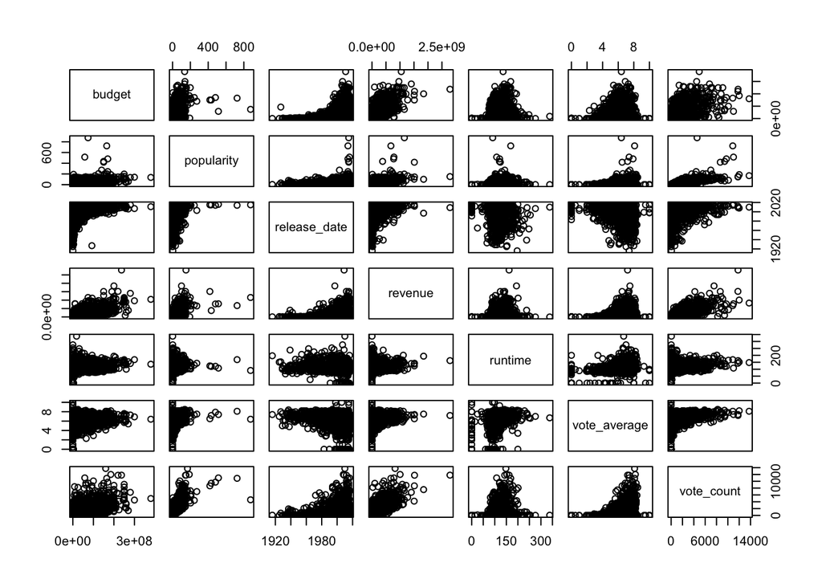

```r
# Graph #1
library(ggplot2)
pairs(movieData)
```

I created a linear model using all features to predict `popularity`. As shown by the summary of the model, `revenue`, `vote_average`, and `vote_count` seem to be the best predictors, as their p-values are close to 0. This makes sense, as a popular movie will have a high ratings (`vote_average`), more people will go to the theatres to see a popular movie (high `revenue`), and even if a movie doesn’t have high ratings, people are more likely to give bad ratings to a movie (`vote_count`) since they know more people will see the rating they gave.

```r
lm <- lm(popularity~., data = movieData)
summary(lm)
```

```
##
## Call:
## lm(formula = popularity ~ ., data = movieData)
##
## Residuals:
##     Min      1Q  Median      3Q     Max
## -118.07   -4.71   -1.07    3.81  768.49
##
## Coefficients:
##                Estimate Std. Error t value Pr(>|t|)
## (Intercept)  -9.981e+01  4.959e+01  -2.013  0.04420 *
## budget        3.352e-08  1.063e-08   3.153  0.00163 **
## release_date  4.986e-02  2.451e-02   2.035  0.04194 *
## revenue       1.384e-08  3.341e-09   4.141 3.52e-05 ***
## runtime      -5.380e-03  1.432e-02  -0.376  0.70721
## vote_average  1.281e+00  2.745e-01   4.667 3.14e-06 ***
## vote_count    1.755e-02  3.896e-04  45.052  < 2e-16 ***
## ---
## Signif. codes:  0 '***' 0.001 '**' 0.01 '*' 0.05 '.' 0.1 ' ' 1
##
## Residual standard error: 19.84 on 4796 degrees of freedom
## Multiple R-squared:  0.6116, Adjusted R-squared:  0.6111
## F-statistic:  1259 on 6 and 4796 DF,  p-value: < 2.2e-16
```

### Data Cleaning (Part 2)

The dataset has been split into 75% training data and 25% testing data.

```r
# Split into testing and training
set.seed(4375)
i <- sample(1:nrow(movieData), nrow(movieData) * 0.75, replace = FALSE)
train <- movieData[i, ]
test <- movieData[-i, ]
```

### Linear Regression (Part 1)

```r
# Linear Regession Model
lm <- lm(popularity~revenue+vote_count+vote_average, data = train)
summary(lm)
```

```
##
## Call:
## lm(formula = popularity ~ revenue + vote_count + vote_average,
##     data = train)
##
## Residuals:
##     Min      1Q  Median      3Q     Max
## -101.64   -5.18   -1.14    4.18  516.89
##
## Coefficients:
##               Estimate Std. Error t value Pr(>|t|)
## (Intercept)  1.240e+00  1.471e+00   0.843    0.399
## revenue      1.403e-08  2.645e-09   5.305 1.20e-07 ***
## vote_count   1.725e-02  3.622e-04  47.622  < 2e-16 ***
## vote_average 1.136e+00  2.437e-01   4.661 3.26e-06 ***
## ---
## Signif. codes:  0 '***' 0.001 '**' 0.01 '*' 0.05 '.' 0.1 ' ' 1
##
## Residual standard error: 16.2 on 3598 degrees of freedom
## Multiple R-squared:  0.6799, Adjusted R-squared:  0.6797
## F-statistic:  2548 on 3 and 3598 DF,  p-value: < 2.2e-16
```

```r
# MSE of Model
paste("MSE:", mean(lm$residuals ^ 2))
```

```
## [1] "MSE: 262.181035179122"
```

### Data Examination (Part 3)

An MSE of 262 is quite high. Using the graph below, we can see why: there are a few outliers that result in extremely high resdiuals.

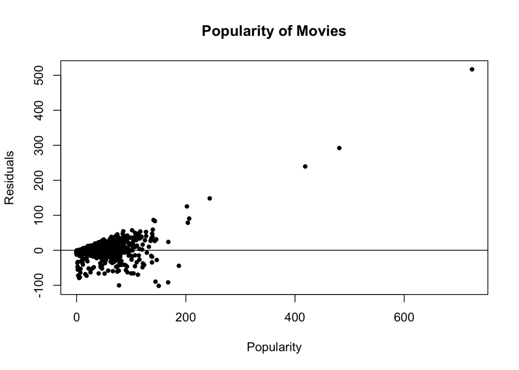

```r
# Graph #2
plot(train$popularity, lm$residuals, ylab="Residuals", xlab="Popularity", main="Popularity of Movies", pch = 20)
abline(0, 0)
```

### Data Cleaning (Part 3)

```r
# Removed outliers
outliers <- movieData[(movieData$popularity > 400),]
outliers
```

```
##        budget popularity release_date    revenue runtime vote_average
## 29  150000000   418.7086         2015 1513528810     124          6.5
## 95  170000000   481.0986         2014  773328629     121          7.9
## 96  165000000   724.2478         2014  675120017     169          8.1
## 128 150000000   434.2786         2015  378858340     120          7.2
## 547  74000000   875.5813         2015 1156730962      91          6.4
## 789  58000000   514.5700         2016  783112979     108          7.4
##     vote_count
## 29        8662
## 95        9742
## 96       10867
## 128       9427
## 547       4571
## 789      10995
```

```r
movieData <- movieData[(movieData$popularity < 400),]
```

Since the overall dataset has been modified (6 examples have been removed), we have to recreate the train and test datasets.

```r
# Recreated train and test sets
i <- sample(1:nrow(movieData), nrow(movieData) * 0.75, replace = FALSE)
train <- movieData[i, ]
test <- movieData[-i, ]
```

### Linear Regression (Part 2)

Now we will create a Linear Regression model without the outliers. This model’s MSE is much lower.

```r
# Linear Regression Model (without outliers)
lm <- lm(popularity~revenue+vote_count+vote_average, data = train)
summary(lm)
```

```
##
## Call:
## lm(formula = popularity ~ revenue + vote_count + vote_average,
##     data = train)
##
## Residuals:
##     Min      1Q  Median      3Q     Max
## -92.253  -5.734  -1.446   4.197 151.707
##
## Coefficients:
##                Estimate Std. Error t value Pr(>|t|)
## (Intercept)  -3.226e-01  1.125e+00  -0.287    0.774
## revenue       2.193e-08  2.069e-09  10.601  < 2e-16 ***
## vote_count    1.491e-02  2.861e-04  52.114  < 2e-16 ***
## vote_average  1.517e+00  1.866e-01   8.126 6.04e-16 ***
## ---
## Signif. codes:  0 '***' 0.001 '**' 0.01 '*' 0.05 '.' 0.1 ' ' 1
##
## Residual standard error: 12.52 on 3593 degrees of freedom
## Multiple R-squared:  0.7447, Adjusted R-squared:  0.7445
## F-statistic:  3494 on 3 and 3593 DF,  p-value: < 2.2e-16
```

```r
# MSE of Model
paste("MSE:", mean(lm$residuals ^ 2))
```

```
## [1] "MSE: 156.557220520918"
```

Looking at the new residual graph (without outliers), we can see that all of the residuals have a magnitude less than 160.

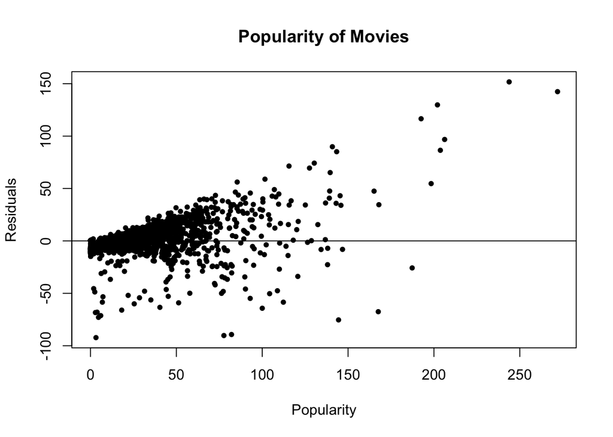

```r
# Graph #2 (without outliers)
plot(train$popularity, lm$residuals, ylab="Residuals", xlab="Popularity", main="Popularity of Movies", pch = 20)
abline(0, 0)
```

```r
# Accuracy for Linear Regression
pred <- predict(lm, newdata = test)
paste("Accuracy: ", round(cor(pred, test$popularity) * 100, 2), "%", sep = "")
```

```
## [1] "Accuracy: 86.99%"
```

### kNN

```r
# kNN
library(caret)
kNNreg <- knnreg(train[, c(3:7)], train[, 2], k = sqrt(nrow(movieData)))
kNNpred <- predict(kNNreg, test[, c(3:7)])
summary(kNNpred)
```

```
##     Min.  1st Qu.   Median     Mean  3rd Qu.     Max.
##   0.3638   7.2560  15.8090  19.5480  26.2014 101.0937
```

```r
# Accuracy for kNN
paste("Accuracy: ", round(cor(kNNpred, test$popularity) * 100, 2), "%", sep = "")
```

```
## [1] "Accuracy: 77.78%"
```

### Scaled kNN

Having all features be on the same scale is a popular technique for improving kNN accuracy. Below is performing kNN on the dataset after the features have been scaled.

```r
# Scaled kNN
df <- data.frame(scale(movieData))
train <- df[i,]
test <- df[-i,]
fit <- knnreg(train[, c(3:7)], train[,2], k = sqrt(nrow(movieData)))
predictions <- predict(fit, test[, c(3:7)])
summary(predictions)
```

```
##     Min.  1st Qu.   Median     Mean  3rd Qu.     Max.
## -0.82822 -0.56513 -0.40200 -0.09350  0.07963  3.52340
```

```r
# Accuracy for Scaled kNN
paste("Accuracy: ", round(cor(predictions, test$popularity) * 100, 2), "%", sep = "")
```

```
## [1] "Accuracy: 89.39%"
```

### Summary & Analysis

Both algorithms performed very well, with Linear Regression resulting in an 86.99% accuracy and kNN resulting in an 89.39% accuracy. Using scaling significantly improved kNN, as it jumped from 77.78% (without scaling) to 89.39% (with scaling) accuracy. Since regression is quite different from classification in that regression will never perfectly make a prediction for a value, I used the correlation between the results from the model on the test data and the actual test data as accuracy.

When it came to kNN, I tested various combinations of the predictors listed in ‘Data Cleaning (Part 1)’, but only removing `budget` seemed to have the largest impact. I found this surprising because I would think a movie with a larger budget would be more popular than a movie with a smaller budget, since most of that money would go towards promotion and marketing, thus making a movie popular.

Also, for comparison, without removing outliers, accuracy was 71.76% for Linear Regression and 69.51% for scaled kNN, so you can see how helpful removing outliers was for this project.

One idea of why scaled kNN performed better than Linear Regression would be that the predictors listed above might have a quadratic-type relationship, meaning that as `budget` or `revenue` increases, `popularity` increases at a much faster rate. kNN can create clusters around movies that perform extremely well, since all of them will have significantly higher `popularity` scores compared to other movies that did not perform as well.